# Participating at useR! 2017

[Hannah Frick](http://www.ucl.ac.uk/~ucakhfr)

# What is *useR!*?

The annual useR! conference is the main meeting of the international *R user and developer* community. Its program consists of both *invited and user-contributed* presentations.

# Topics

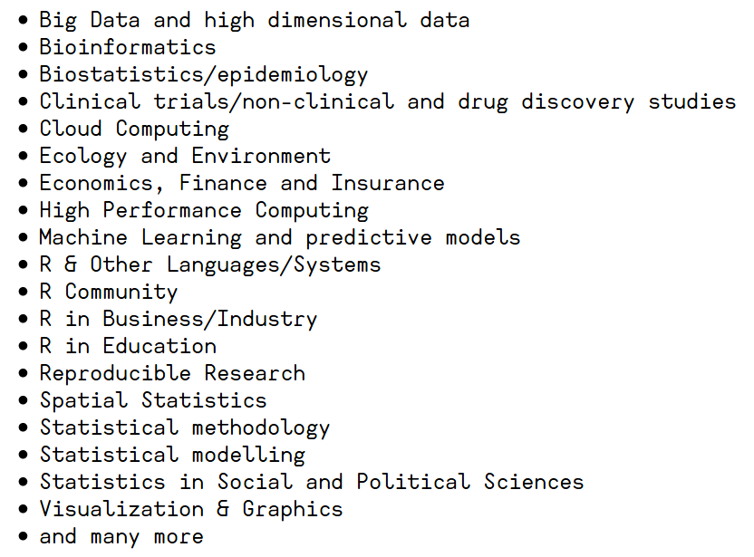

# When, where, how?

- Where: Brussels, Belgium
- When: July 4 - 7, 2017
- *Childcare*!
- Scholarships:
  - Diversity Scholarships
  - Young Academics Scholarship

# Keynotes

- [Yves Rosseel](http://users.ugent.be/~yrosseel/): Structural equation modelling
- [Norm Matloff](http://heather.cs.ucdavis.edu/matloff.html): R programming
- [Isabella Gollini](http://www.bbk.ac.uk/ems/faculty/gollini/gollini): Natural hazards/network data/spatial analysis
- [Mine Cetinkaya-Rundel](http://www2.stat.duke.edu/~mc301/): Teaching R
- [Ludwig Hothorn](https://www.biostat.uni-hannover.de/11.html?&no_cache=1&tx_tkinstpersonen_pi1%5BshowUid%5D=1): Dose-response modelling in R
- [Uwe Ligges](https://www.statistik.tu-dortmund.de/ligges.html): CRAN

# Tutorials 2016

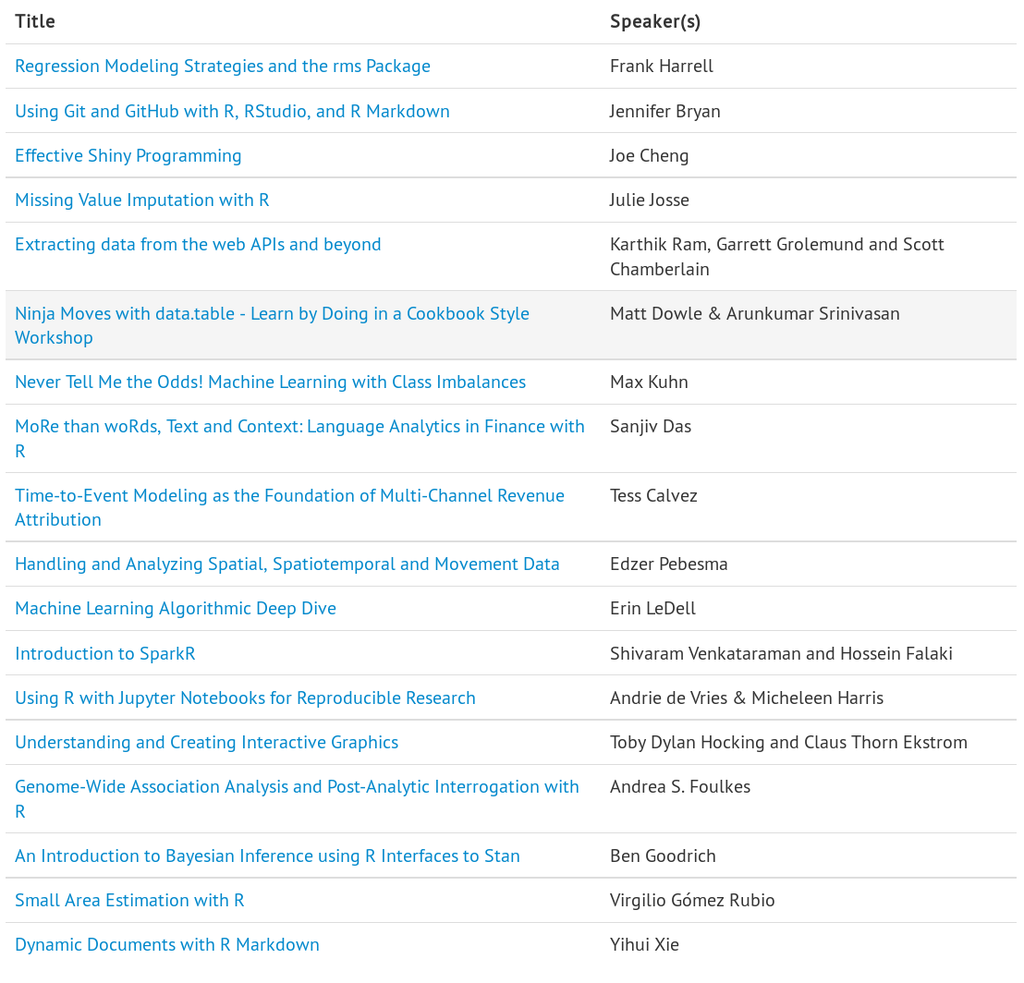

# Tutorials 2017

[figure not shown]

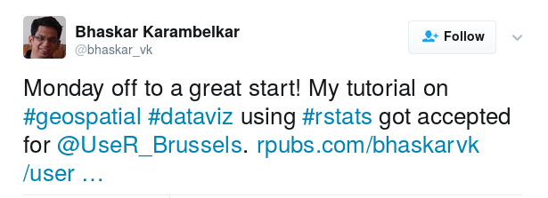

# Ways of participating

- Attend
- Give a talk
- Give a lightning talk
- Present a poster
- Program committee might suggest moving it to another category if they feel that’s a better fit

# Talks

- 15-20 minutes, “free” discussion format
- Focus on:
  - applications of R for a wide audience
  - topics of special interest
  - technical topics
- Typically with a stronger methodological component
- Examples: new package, implementation of an algorithm, novel use of existing packages, comparison of how your approach compares to traditional methods, …

# Alternatives

**Lightning Talks**

- Oral presentations of 5 minutes
- Fixed format: slides move automatically!
- Speak on any R-related topic
- Should particularly appeal to R newbies

**Posters**

- Shorter and less novel presentations of the usage of R to be enjoyed with drinks and light snacks.

# Abstracts

- Template provided on submission page https://user2017.brussels/abstracts
- Markup such as code blocks, displayed equations, and lists should be used sparingly (if at all), to keep the abstract short.
- Abstracts should not exceed one side of A4 paper when printed and should not include images.
- Write vague enough for small adjustments.
- Write specific enough for the program committee to be able to judge it accurately.

# Register!

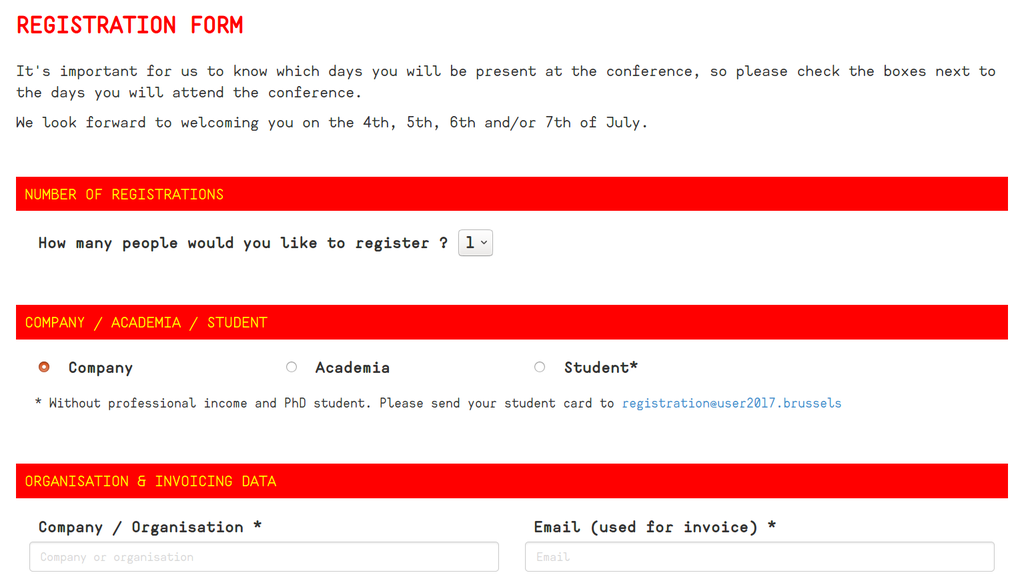

# Submit your abstract!

[figure not shown]